# Data representation with R IV

Specialist graphs, PCA, heatmaps, composition and export

O Rodriguez de Rivera Ortega, PhD

University of Exeter

```r
library(tidyverse)
library(palmerpenguins)
library(scales)
library(viridis)
library(patchwork)

theme_set(theme_minimal(base_size = 12))

penguins_clean <- penguins %>%
  drop_na(species, island, bill_length_mm, bill_depth_mm,
          flipper_length_mm, body_mass_g, sex)
```

# 1 Specialist graphs

## 1.1 When do we need specialist graphs?

Use specialist graphs when the standard graph does not answer the question clearly.

Examples:

- bubble charts for two quantitative variables plus a third magnitude;
- heatmaps for matrices and correlations;
- scatterplot matrices for many pairwise relationships;
- PCA biplots for multivariate structure;
- composed figures for reports and papers;
- interactive graphics for exploration.

# 2 Bubble charts

## 2.1 Bubble chart

A bubble chart is a scatterplot where point size encodes a third quantitative variable.

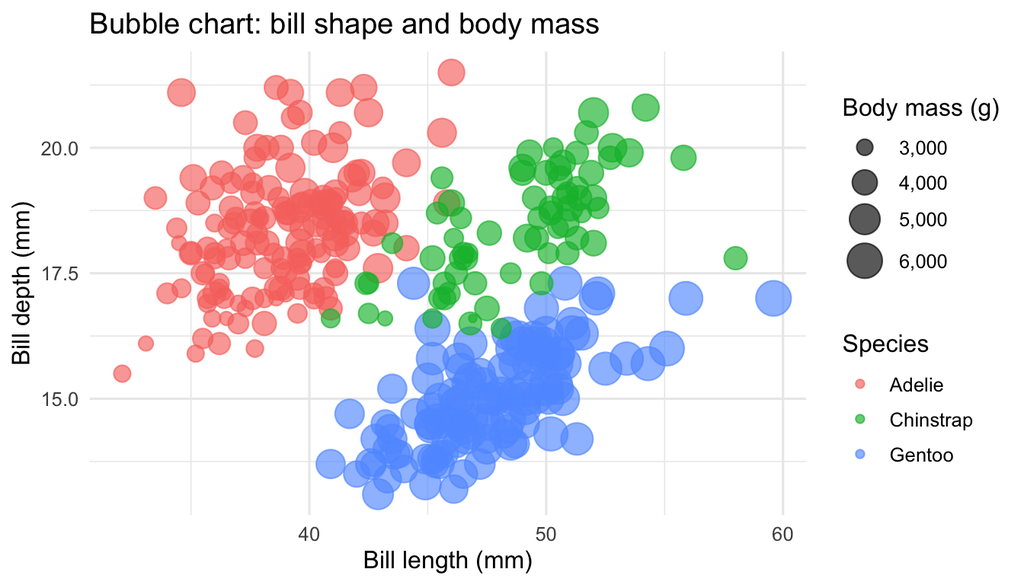

```r
ggplot(penguins_clean,
       aes(x = bill_length_mm, y = bill_depth_mm,
           size = body_mass_g, colour = species)) +
  geom_point(alpha = 0.65) +
  scale_size_continuous(range = c(1.5, 8), labels = comma) +
  labs(
    title = "Bubble chart: bill shape and body mass",
    x = "Bill length (mm)",
    y = "Bill depth (mm)",
    size = "Body mass (g)",
    colour = "Species"
  )
```

## 2.2 Bubble chart warning

Size is less precise than position. Use bubble charts for broad patterns, not exact comparisons.

Better alternatives can include:

- facets by category;
- direct labels;
- separate plots;
- a table for exact values.

# 3 Heatmaps

## 3.1 Correlation heatmap

```r
cor_data <- penguins_clean %>%
  select(bill_length_mm, bill_depth_mm, flipper_length_mm, body_mass_g) %>%
  cor(use = "complete.obs") %>%
  as.data.frame() %>%
  rownames_to_column("var1") %>%
  pivot_longer(-var1, names_to = "var2", values_to = "correlation")

head(cor_data)
```

| var1 | var2 | correlation |
| --- | --- | --- |
| bill_length_mm | bill_length_mm | 1.0000000 |
| bill_length_mm | bill_depth_mm | -0.2286256 |
| bill_length_mm | flipper_length_mm | 0.6530956 |
| bill_length_mm | body_mass_g | 0.5894511 |
| bill_depth_mm | bill_length_mm | -0.2286256 |
| bill_depth_mm | bill_depth_mm | 1.0000000 |

## 3.2 Plot the correlation heatmap

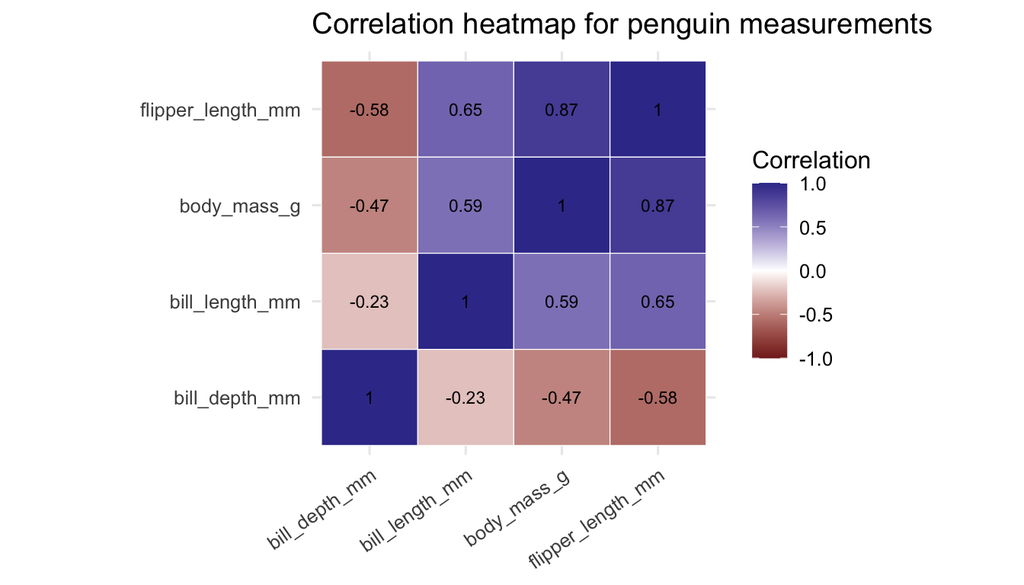

```r
ggplot(cor_data, aes(x = var1, y = var2, fill = correlation)) +
  geom_tile(colour = "white") +
  geom_text(aes(label = round(correlation, 2)), size = 3) +
  scale_fill_gradient2(limits = c(-1, 1)) +
  coord_equal() +
  labs(
    title = "Correlation heatmap for penguin measurements",
    x = NULL,
    y = NULL,
    fill = "Correlation"
  ) +
  theme(axis.text.x = element_text(angle = 35, hjust = 1))
```

## 3.3 Heatmap of standardised values

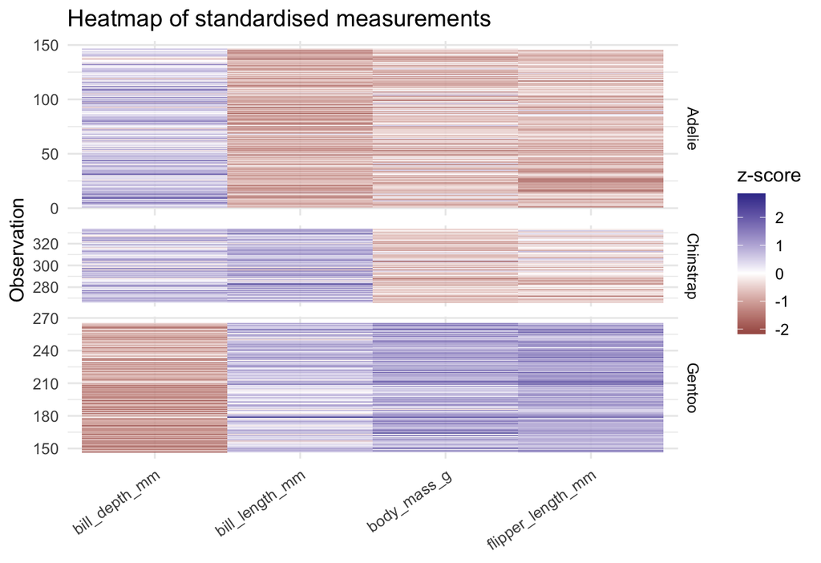

```r
penguin_z <- penguins_clean %>%
  select(species, island, bill_length_mm, bill_depth_mm,
         flipper_length_mm, body_mass_g) %>%
  mutate(row_id = row_number()) %>%
  mutate(across(where(is.numeric) & !row_id, scale)) %>%
  pivot_longer(c(bill_length_mm, bill_depth_mm,
                 flipper_length_mm, body_mass_g),
               names_to = "variable", values_to = "z")

ggplot(penguin_z, aes(x = variable, y = row_id, fill = z)) +
  geom_tile() +
  facet_grid(species ~ ., scales = "free_y", space = "free_y") +
  scale_fill_gradient2() +
  labs(
    title = "Heatmap of standardised measurements",
    x = NULL,
    y = "Observation",
    fill = "z-score"
  ) +
  theme(axis.text.x = element_text(angle = 35, hjust = 1))
```

# 4 Scatterplot matrices

## 4.1 Base R scatterplot matrix

Scatterplot matrices are useful for exploration, but they can be too busy for a final report.

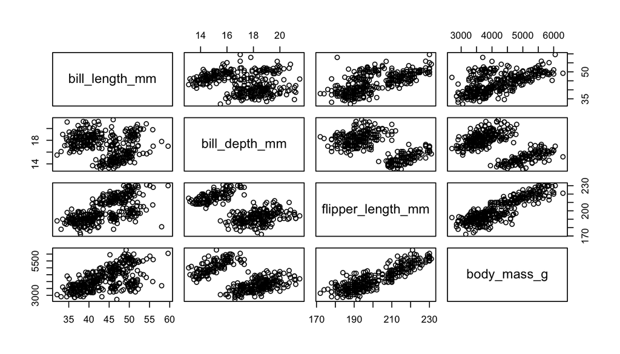

```r
penguins_clean %>%
  select(bill_length_mm, bill_depth_mm, flipper_length_mm, body_mass_g) %>%
  pairs()
```

## 4.2 `GGally::ggpairs()` option

```r
library(GGally)

penguins_clean %>%
  select(species, bill_length_mm, bill_depth_mm,
         flipper_length_mm, body_mass_g) %>%
  GGally::ggpairs(aes(colour = species, alpha = 0.5))
```

# 5 PCA and biplots

## 5.1 Run PCA

PCA is useful for summarising several correlated quantitative variables.

```r
penguin_pca_data <- penguins_clean %>%
  select(bill_length_mm, bill_depth_mm, flipper_length_mm, body_mass_g)

penguin_pca <- prcomp(penguin_pca_data, center = TRUE, scale. = TRUE)

summary(penguin_pca)
```

```
## Importance of components:
##                           PC1    PC2     PC3     PC4
## Standard deviation     1.6569 0.8821 0.60716 0.32846
## Proportion of Variance 0.6863 0.1945 0.09216 0.02697
## Cumulative Proportion  0.6863 0.8809 0.97303 1.00000
```

## 5.2 PCA scores

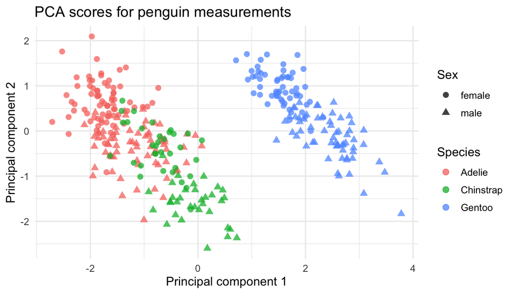

```r
pca_scores <- as_tibble(penguin_pca$x[, 1:2]) %>%
  bind_cols(penguins_clean %>% select(species, island, sex))

ggplot(pca_scores, aes(x = PC1, y = PC2, colour = species, shape = sex)) +
  geom_point(alpha = 0.75, size = 2.4) +
  labs(
    title = "PCA scores for penguin measurements",
    x = "Principal component 1",
    y = "Principal component 2",
    colour = "Species",
    shape = "Sex"
  )
```

## 5.3 Manual biplot

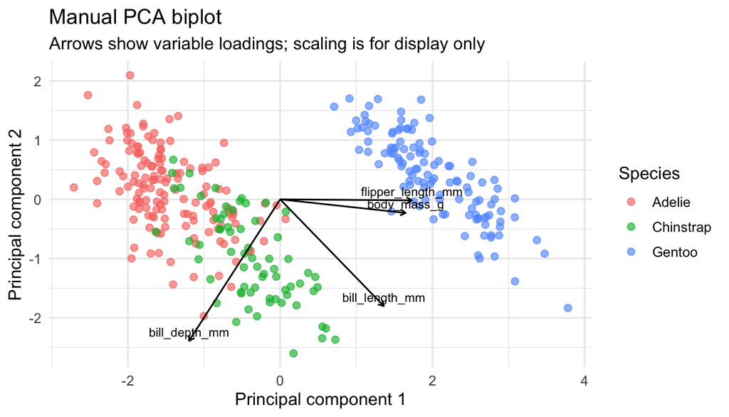

```r
pca_loadings <- as_tibble(penguin_pca$rotation[, 1:2], rownames = "variable") %>%
  mutate(PC1 = PC1 * 3, PC2 = PC2 * 3)

ggplot(pca_scores, aes(x = PC1, y = PC2, colour = species)) +
  geom_point(alpha = 0.65, size = 2) +
  geom_segment(data = pca_loadings,
               aes(x = 0, y = 0, xend = PC1, yend = PC2),
               inherit.aes = FALSE,
               arrow = arrow(length = unit(0.15, "cm"))) +
  geom_text(data = pca_loadings,
            aes(x = PC1, y = PC2, label = variable),
            inherit.aes = FALSE,
            nudge_y = 0.15, size = 3) +
  labs(
    title = "Manual PCA biplot",
    subtitle = "Arrows show variable loadings; scaling is for display only",
    x = "Principal component 1",
    y = "Principal component 2",
    colour = "Species"
  )
```

## 5.4 Interpreting biplots

- Points close together have similar multivariate measurements.
- Long arrows indicate variables that contribute strongly to the displayed components.
- Arrows pointing in a similar direction indicate positive association.
- Biplots are approximate: always check how much variance PC1 and PC2 explain.

# 6 Composing figures

## 6.1 Patchwork

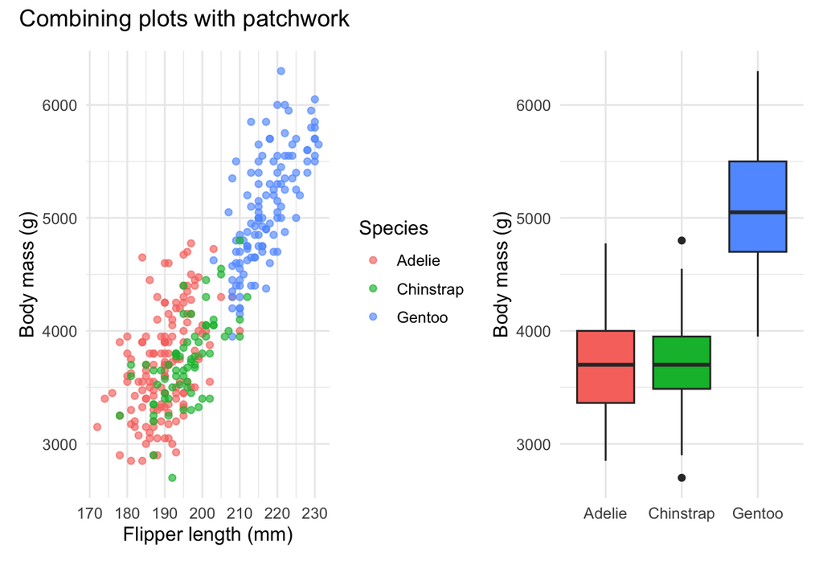

```r
p_scatter <- ggplot(penguins_clean,
                    aes(x = flipper_length_mm, y = body_mass_g, colour = species)) +
  geom_point(alpha = 0.65) +
  labs(x = "Flipper length (mm)", y = "Body mass (g)", colour = "Species")

p_box <- ggplot(penguins_clean, aes(x = species, y = body_mass_g, fill = species)) +
  geom_boxplot(show.legend = FALSE) +
  labs(x = NULL, y = "Body mass (g)")

p_scatter + p_box +
  plot_annotation(title = "Combining plots with patchwork")
```

# 7 Interactive graphics

## 7.1 Plotly for exploration

Interactive plots can be useful during analysis, but static plots are usually better for printed reports.

```r
library(plotly)

p <- ggplot(penguins_clean,
            aes(x = flipper_length_mm, y = body_mass_g,
                colour = species,
                text = paste("Island:", island))) +
  geom_point(alpha = 0.7) +
  labs(
    title = "Interactive penguin scatterplot",
    x = "Flipper length (mm)",
    y = "Body mass (g)"
  )

ggplotly(p, tooltip = c("x", "y", "colour", "text"))
```

# 8 Exporting graphics

## 8.1 Save a plot

Use `ggsave()` for reproducible exporting.

```r
p <- ggplot(penguins_clean,
            aes(x = flipper_length_mm, y = body_mass_g, colour = species)) +
  geom_point(alpha = 0.7) +
  labs(
    title = "Body mass and flipper length",
    x = "Flipper length (mm)",
    y = "Body mass (g)",
    colour = "Species"
  )

ggsave("penguin_scatter.png", plot = p, width = 7, height = 5, dpi = 300)
ggsave("penguin_scatter.pdf", plot = p, width = 7, height = 5)
```

## 8.2 Export checklist

- Use vector formats (`.pdf`, `.svg`) for line art and publication figures.
- Use high-resolution `.png` for slides or web outputs.
- Set `width`, `height` and `dpi` deliberately.
- Check font sizes after exporting.
- Never export by screenshot unless it is unavoidable.

# 9 Final exercise

## 9.1 Exercise 6: mini visualisation task

Choose one dataset: `penguins_clean`, `gapminder`, `mpg`, or your own data.

Prepare a small figure set with:

1. one univariate graph;
2. one bivariate graph;
3. one multivariate graph using colour, facets or size;
4. one sentence explaining the main message of each plot.

Extension:

- combine the plots with `patchwork`;
- save the final figure with `ggsave()`;
- make one exploratory interactive version with `plotly`.

## 9.2 Wrap-up

Key messages:

- choose the graph from the data type and question;
- start simple and add complexity only when it helps;
- show raw data when possible;
- labels, units and scale choices are part of the analysis;
- visualisation is an iterative process.